[output not shown]

Expression profiling of hypoxic HepG2 hepatoma, U87 glioma, and MDA-MB231 breast cancer cells: time course (E-GEOD-18494)

Analysis of expression changes of cultured HepG2 hepatoma, U87 glioma, and MDA-MB231 breast cancer cells subjected to hypoxia (0.5% O2) for 0, 4, 8, 12 hours . Results provide insight to cell type-specific response to hypoxia. HepG2 hepatoma, U87 glioma, and MDA-MB231 breast cancer cells were collected under normoxic conditions (~19% O2, 0 hours) and after 4, 8 and 12 hours of hypoxia treatment (0.5% O2). For each cell line, three replicates of total RNA at each time point were prepared using Trizol and submitted to the DFCI Microarray Core for labeling, hybridization to Affymetrix HG-U133Plus2 oligonucleotide arrays and image scanning.

https://www.ebi.ac.uk/arrayexpress/experiments/E-GEOD-18494/

This pipeline if based on the Workflow :

https://www.bioconductor.org/packages/devel/workflows/vignettes/maEndToEnd/inst/doc/MA-Workflow.html

```r
packages_bioconductor = c("Biobase","ArrayExpress", "hgu133plus2.db", "oligo", "DESeq2", "Glimma", "limma", "clusterProfiler", "topGO")

# Install and load packages
package.check <- lapply(packages_bioconductor, FUN = function(x) {
  if (!require(x, character.only = TRUE)) {
    BiocManager::install(x, dependencies = TRUE)
    library(x, character.only = TRUE)
  }
})

packages_cran = c("DT", "tidyverse","dplyr", "tibble", "data.table", "stats", "ggpubr", "ggplot2", "RColorBrewer", "ggrepel", "pheatmap","ComplexHeatmap", "gapminder", "ggstatsplot", "fs")

# For ggstatsplot, might be needed execute:
# sudo apt-get install libgmp-dev
# sudo apt-get install libmpfr-dev

# Install and load packages
package.check <- lapply(packages_cran, FUN = function(x) {
  if (!require(x, character.only = TRUE)) {
    install.packages(x, dependencies = TRUE)
    library(x, character.only = TRUE)
  }
})

rm(package.check, packages_bioconductor, packages_cran)
```

# Import of annotation data and microarray expression data as “ExpressionSet”

```r
download_dir <- fs::path(".data_tmp")
if (!dir_exists(download_dir)) {
    dir_create(download_dir)
    EGEOD18494 <- ArrayExpress( "E-GEOD-18494", save=TRUE, path=download_dir)
} else {
    EGEOD18494 <- ArrayExpress( "E-GEOD-18494", save=TRUE, path=download_dir)
}
```

[output not shown]

```r
data.EGEOD18494 <- pData(EGEOD18494)

data.EGEOD18494 <- data.frame(
                  codes = substr(data.EGEOD18494$Source.Name,1,9),
                  cell_line = data.EGEOD18494$Characteristics..cell.line.,
                  time = data.EGEOD18494$Characteristics..time,
                  condition = data.EGEOD18494$Characteristics..stress.
                  )
data.EGEOD18494 <- data.EGEOD18494[order(data.EGEOD18494$codes),]
data.EGEOD18494$rep <- rep(1:3, n= length(data.EGEOD18494$codes))


eset.EGEOD18494 <- oligo::rma(EGEOD18494,  normalize = FALSE)
```

```
## Background correcting
## Calculating Expression
```

```r
exp.EGEOD18494 <- exprs(eset.EGEOD18494)

colnames(exp.EGEOD18494) <- substr(colnames(exp.EGEOD18494),1,9)

EGEOD18494@annotation
```

```
## [1] "pd.hg.u133.plus.2"
```

```r
rm(download_dir)
```

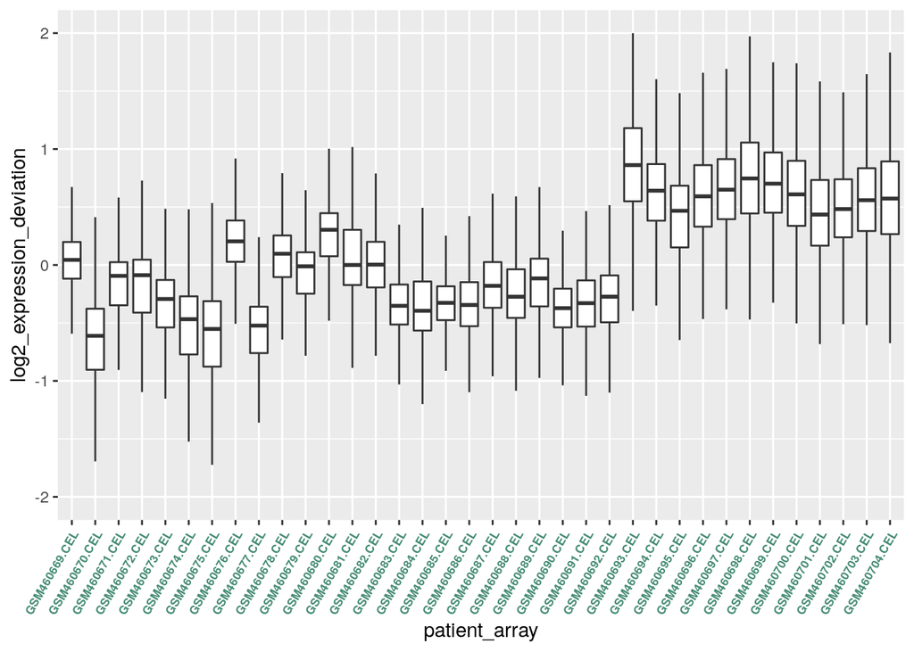

```r
row_medians_assayData <-
  Biobase::rowMedians(as.matrix(Biobase::exprs(eset.EGEOD18494)))

RLE_data <- sweep(Biobase::exprs(eset.EGEOD18494), 1, row_medians_assayData)

RLE_data <- as.data.frame(RLE_data)
RLE_data_gathered <-
  tidyr::gather(RLE_data, patient_array, log2_expression_deviation)

ggplot2::ggplot(RLE_data_gathered, aes(patient_array,
                                       log2_expression_deviation)) +
  geom_boxplot(outlier.shape = NA) +
  ylim(c(-2, 2)) +
  theme(axis.text.x = element_text(colour = "aquamarine4",
                                  angle = 60, size = 6.5, hjust = 1 ,
                                  face = "bold"))
```

```r
rm(RLE_data, RLE_data_gathered, row_medians_assayData)
```

Note that the y-axis now displays for each sample the deviation of expression intensity from the median expression of the respective single transcripts across arrays.

Boxes with a larger extension therefore indicate an unusually high deviation from the median in a lot of transcripts, suggesting that these arrays are different from most of the others in some way.

Boxes that are shifted in y-direction indicate a systematically higher or lower expression of the majority of transcripts in comparison to most of the other arrays. This could be caused by quality issues or batch effects.

Therefore, if shape and median of a given box varies too much from the bulk, they should be inspected and potentially removed.

Checking the intensity distributions of the individual arrays, it they are quite different, this indicates the need for an appropriate normalization.

```r
EGEOD18494_norm <- oligo::rma(EGEOD18494, normalize = TRUE)
```

```
## Background correcting
## Normalizing
## Calculating Expression
```

```r
rm(eset.EGEOD18494)
```

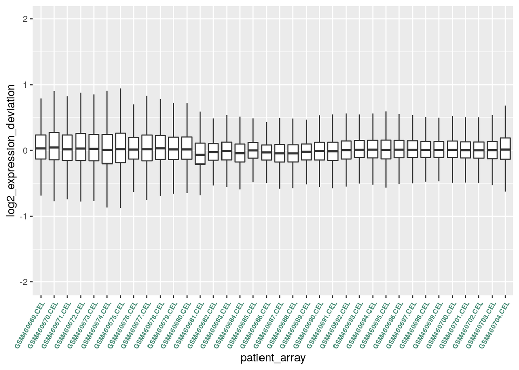

```r
row_medians_assayData <-
  Biobase::rowMedians(as.matrix(Biobase::exprs(EGEOD18494_norm)))

RLE_data <- sweep(Biobase::exprs(EGEOD18494_norm), 1, row_medians_assayData)

RLE_data <- as.data.frame(RLE_data)
RLE_data_gathered <-
  tidyr::gather(RLE_data, patient_array, log2_expression_deviation)

ggplot2::ggplot(RLE_data_gathered, aes(patient_array,
                                       log2_expression_deviation)) +
  geom_boxplot(outlier.shape = NA) +
  ylim(c(-2, 2)) +
  theme(axis.text.x = element_text(colour = "aquamarine4",
                                  angle = 60, size = 6.5, hjust = 1 ,
                                  face = "bold"))
```

```r
rm(RLE_data, RLE_data_gathered, row_medians_assayData)
```

```r
anno.EGEOD18494 <- AnnotationDbi::select(hgu133plus2.db, keys=rownames(exp.EGEOD18494), columns=c("ENSEMBL", "SYMBOL", "GENENAME"), keytype="PROBEID")
colnames(anno.EGEOD18494) <- c("probes", "ensgene", "symbol", "description")
```

# Quality control of the raw data: PCA of Samples

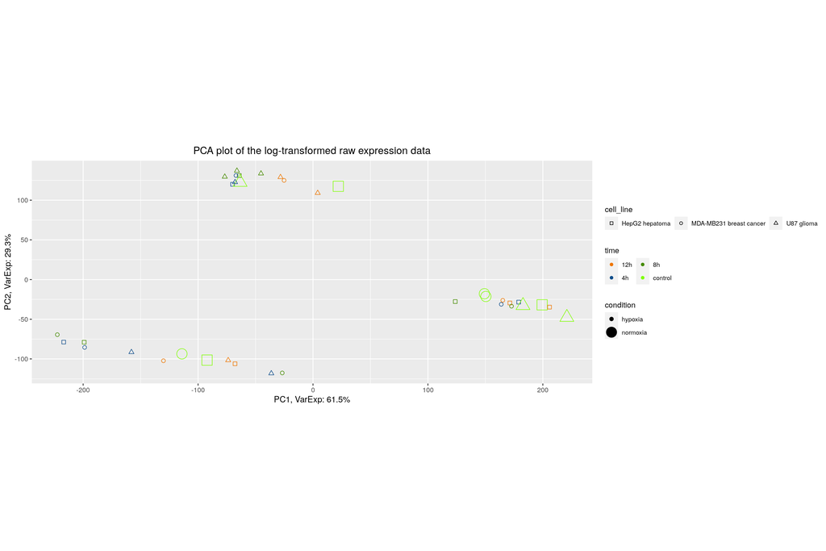

```r
PCA_raw <- prcomp(t(exp.EGEOD18494), scale. = FALSE)

percentVar <- round(100*PCA_raw$sdev^2/sum(PCA_raw$sdev^2),1)
sd_ratio <- sqrt(percentVar[2] / percentVar[1])

dataGG <- cbind(data.frame(PC1 = PCA_raw$x[,1], PC2 = PCA_raw$x[,2]), data.EGEOD18494)

col3 <- guide_legend(ncol = 3)
ggplot(dataGG, aes(PC1, PC2)) +
  geom_point(aes(shape = cell_line, colour = time, size = condition)) +
# geom_point(colour = condition, size = 1) +
  ggtitle("PCA plot of the log-transformed raw expression data") +
  xlab(paste0("PC1, VarExp: ", percentVar[1], "%")) +
  ylab(paste0("PC2, VarExp: ", percentVar[2], "%")) +
  theme(plot.title = element_text(hjust = 0.5))+
  coord_fixed(ratio = sd_ratio) +
  scale_shape_manual(values = c(0, 1, 2), guide = col3) +
  scale_color_manual(values = c("darkorange2", "dodgerblue4", "chartreuse4", "chartreuse1"), guide = col3) +
  guides(fill=guide_legend(ncol=3)) +
  theme(
    legend.title = element_text(size = 10),
    legend.text = element_text(size = 8)
  )
```

```r
rm(col3, dataGG, PCA_raw, sd_ratio, percentVar)
```

# MultiDimension Scaling plots by conditions and time

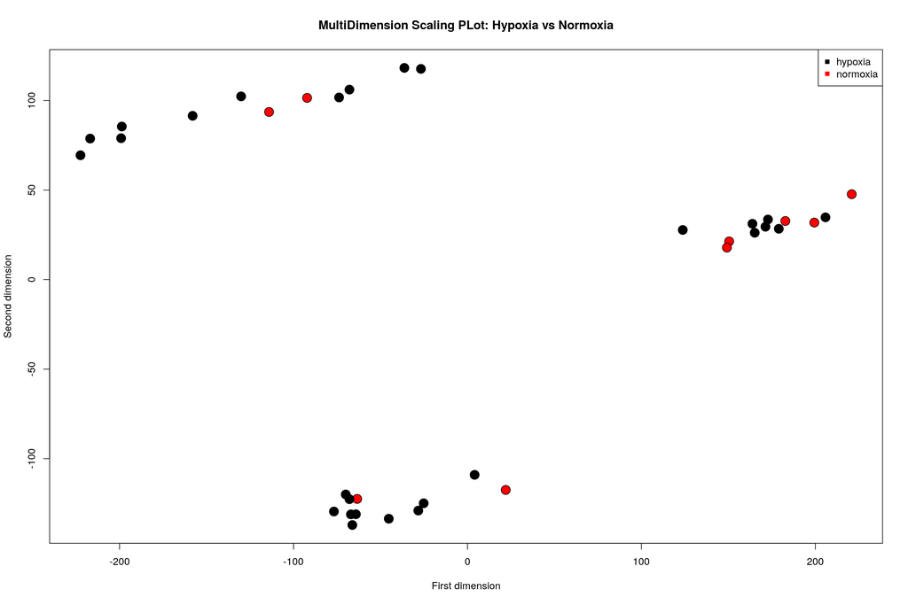

```
## integer(0)
```

```r
dist_matrix<- dist(t(exp.EGEOD18494)) # very important to take transpose "t"
mds <- cmdscale(dist_matrix)

plot(mds[,1],mds[,2],bg=as.numeric(data.EGEOD18494$condition),
     pch=21,xlab="First dimension",ylab="Second dimension",
     cex=2,main="MultiDimension Scaling PLot: Hypoxia vs Normoxia")
legend("topright",levels(data.EGEOD18494$condition),col=seq(along=levels(data.EGEOD18494$condition)),pch=15,cex=1)
identify(mds)
```

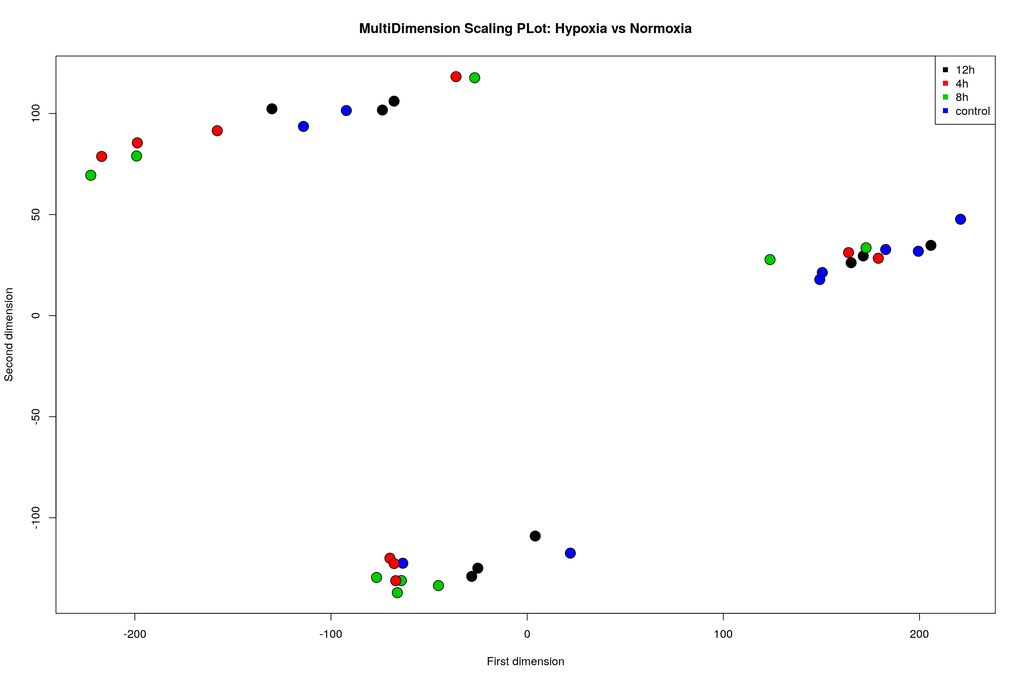

```
## integer(0)
```

```r
plot(mds[,1],mds[,2],bg=as.numeric(data.EGEOD18494$time),
     pch=21,xlab="First dimension",ylab="Second dimension",
     cex=2,main="MultiDimension Scaling PLot: Hypoxia vs Normoxia")
legend("topright",levels(data.EGEOD18494$time),col=seq(along=levels(data.EGEOD18494$time)),pch=15,cex=1)
identify(mds)
```

```r
rm(mds,dist_matrix)
```

# Heatmap clustering analysis

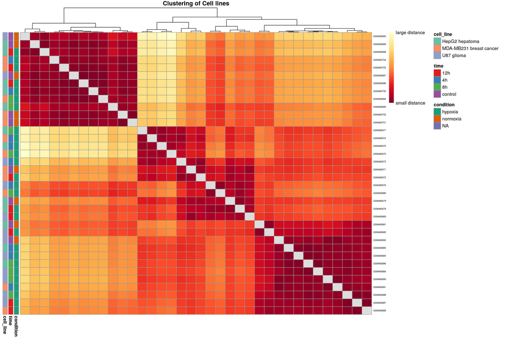

```r
annotation_for_heatmap <-
  data.frame(condition = data.EGEOD18494$condition,
             time = data.EGEOD18494$time,
             cell_line = data.EGEOD18494$cell_line
             )

row.names(annotation_for_heatmap) <- colnames(exp.EGEOD18494)

dists <- as.matrix(dist(t(exp.EGEOD18494), method = "manhattan"))

rownames(dists) <- colnames(exp.EGEOD18494)
hmcol <- rev(colorRampPalette(RColorBrewer::brewer.pal(9, "YlOrRd"))(255))
colnames(dists) <- NULL
diag(dists) <- NA

ann_colors <- list(
  condition = brewer.pal(length(levels(data.EGEOD18494$condition)), "Dark2"),
  time = brewer.pal(length(levels(data.EGEOD18494$time)), "Set1"),
  cell_line = brewer.pal(length(levels(data.EGEOD18494$cell_line)), "Set2")
)
names(ann_colors$condition) <- levels(data.EGEOD18494$condition)
names(ann_colors$time) <- levels(data.EGEOD18494$time)
names(ann_colors$cell_line) <- levels(data.EGEOD18494$cell_line)

pheatmap(dists, col = (hmcol),
         annotation_row = annotation_for_heatmap,
         annotation_colors = ann_colors,
         legend = TRUE,
         treeheight_row = 0,
         legend_breaks = c(min(dists, na.rm = TRUE),
                           max(dists, na.rm = TRUE)),
         legend_labels = (c("small distance", "large distance")),
         main = "Clustering of Cell lines",
         fontsize_row = 5)
```

```r
rm(ann_colors, hmcol, dists, annotation_for_heatmap )
```

# Selecting the HIF Genes

```r
# Genes from "Dynamical analysis of a generic Boolean model for the control of the mammalian cell cycle"
# Adrien Fauré  1 , Aurélien Naldi, Claudine Chaouiya, Denis Thieffry
# PMID: 16873462 DOI: 10.1093/bioinformatics/btl210
# CycD Rb E2F CycE CycA p27 Cdc20 Cdh1 UbcH10 CycB

# Genes from Our Boolean Network:
# HIF1a, HIF2a, p53, BNIP3, VEGF, cMyc, Oct4, cdc20, cycA, cycB, cycE, cycD, p27, Rb, E2F, cdh1, mdm2, BAD, BclX

hif.symbols <- c("HIF1A", "HIF1", "PASD8", "MOP1", "EPAS1", "HIF2A", "HLF", "PASD2", "MOP2", "VEGFA", "VPF", "MVCD1", "VEGF-A", "TP53", "P53", "MYC", "C-Myc", "POU5F1", "OCT3", "OTF3", "CDC20", "P55CDC", "CDC20A", "CCNA1", "CCNA1", "CCNA2", "CCN1", "CCNA", "CCNB1", "CCNB", "CCNB1", "CCNB2", "CCNB2", "HsT17299", "CCND1", "PRAD1", "CCND2", "MPPH3", "CCNE1", "CCNE1", "CCNE", "PCCNE1", "CCNE2", "CCNE2", "CCNE", "PCCNE1", "CDKN1B", "KIP1", "P27KIP1", "CDKN4MEN4", "RB1", "PPP1R130", "Pp110", "E2F1", "RBAP-1", "BNIP3", "NIP3", "BCL2", "MCL1", "BCL2L3", "CDH1", "CD324", "UBE2C", "BAD", "BCL2L8", "VHL", "PVHL", "VHL1", "MDM2", "HDM2", "EP300", "P300", "KAT3B")

hif.probes <- anno.EGEOD18494$probes[anno.EGEOD18494$symbol %in% hif.symbols]

exp.EGEOD18494.hif <- data.frame(exp.EGEOD18494) %>%
  rownames_to_column('probes') %>%
  filter(probes %in% hif.probes) %>%
  merge(anno.EGEOD18494[anno.EGEOD18494$symbol %in% hif.symbols, c("probes","symbol")], by = "probes") %>%
  distinct(symbol, .keep_all = TRUE) %>%
  select(!(probes))

# Saving data with data description on columns
exp.EGEOD18494.hif %>%
  rename_at(vars(data.EGEOD18494$codes),
            ~paste0(substr(data.EGEOD18494$condition,1,4),".",
                    data.EGEOD18494$time,".",
                    substr(data.EGEOD18494$cell_line,1,1), ".",
                    data.EGEOD18494$rep)) %>%
  write.csv(., file = "data/exp.EGEOD18494.hif.csv", row.names = T)
```

```r
exp.EGEOD18494.hif.pivot <- exp.EGEOD18494.hif %>%
  group_by(symbol) %>%
  pivot_longer(cols = starts_with("GSM"), names_to = "codes", values_to = "value") %>%
  merge(data.EGEOD18494, by = "codes") %>%
  mutate(
    time = factor(time, levels = c("control", "4h" , "8h" , "12h"))
  )
```

# Comparing expression per cell line

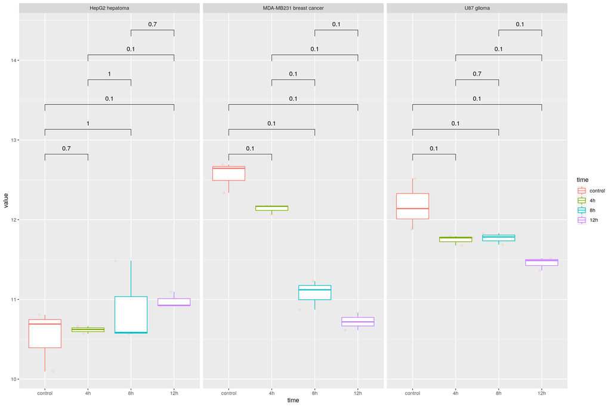

```r
my_comparisons=list(c("control","4h"), c("control","8h"), c("control","12h"), c("4h","8h"), c("4h","12h"), c("8h","12h"))

ggplot(exp.EGEOD18494.hif.pivot[exp.EGEOD18494.hif.pivot$symbol == c('HIF1A'), ], aes(x = time, y = value, group = time, color = time)) +
    geom_jitter(alpha = 0.1, color = "tomato") +
    geom_boxplot() + facet_wrap(~ cell_line) + stat_compare_means(comparisons=my_comparisons)
```

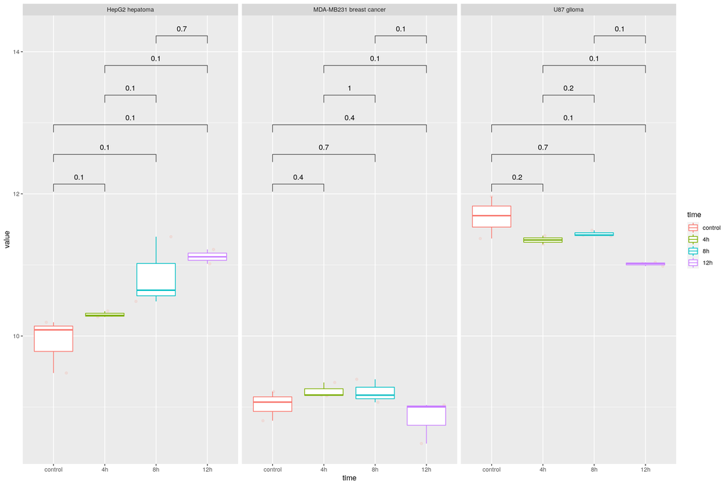

```r
ggplot(exp.EGEOD18494.hif.pivot[exp.EGEOD18494.hif.pivot$symbol == c('EPAS1'), ], aes(x = time, y = value, group = time, color = time)) +
    geom_jitter(alpha = 0.1, color = "tomato") +
    geom_boxplot() + facet_wrap(~ cell_line) + stat_compare_means(comparisons=my_comparisons)
```

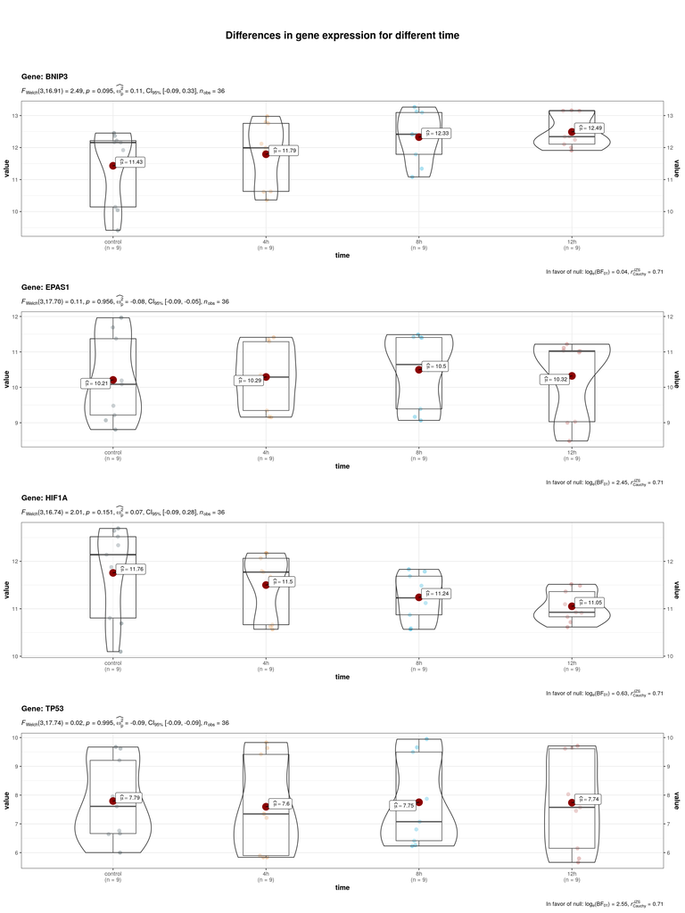

```r
ggstatsplot::grouped_ggbetweenstats(
  data = exp.EGEOD18494.hif.pivot[exp.EGEOD18494.hif.pivot$symbol %in%  c('HIF1A', 'EPAS1', 'TP53', 'BNIP3'),],
  x = time,
  y = value,
  grouping.var = symbol, # grouping variable
  ggplot.component = list(ggplot2::scale_y_continuous(sec.axis = ggplot2::dup_axis())),
#  k = 4,
  title.prefix = "Gene",
  palette = "default_jama",
  package = "ggsci",
  plotgrid.args = list(nrow = 4),
  title.text = "Differences in gene expression for different time",
  messages = FALSE
)
```

# Another comparison visualization

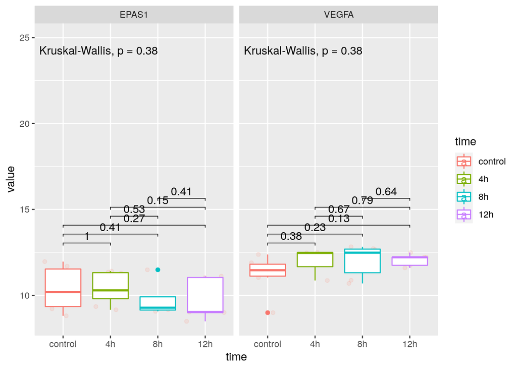

```r
  ggplot(exp.EGEOD18494.hif.pivot[exp.EGEOD18494.hif.pivot$symbol == c('EPAS1', 'VEGFA'), ], aes(x = time, y = value, group = time, color = time)) +
    geom_jitter(alpha = 0.1, color = "tomato") +
    geom_boxplot() +
    facet_wrap(~ symbol)  +
    stat_compare_means(comparisons=my_comparisons)  +
    stat_compare_means(label.y = 25, vjust = 2)
```

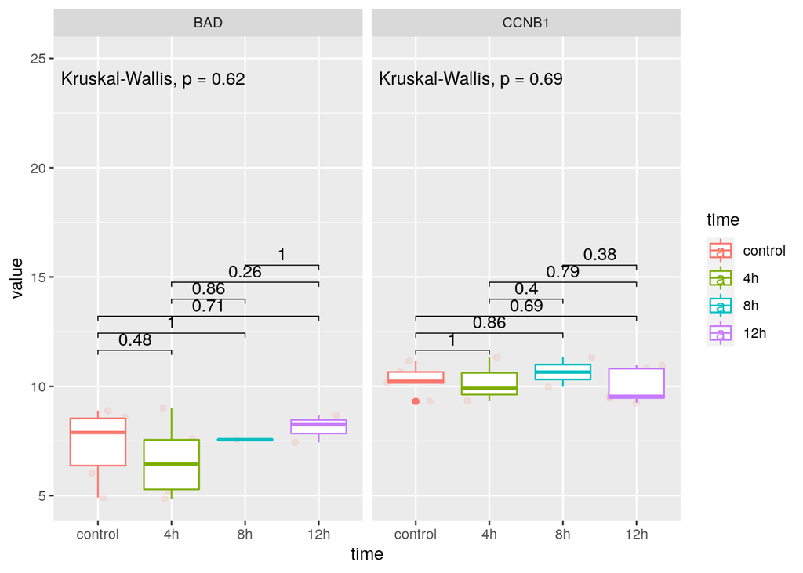

```r
  ggplot(exp.EGEOD18494.hif.pivot[exp.EGEOD18494.hif.pivot$symbol == c('CCNB1', 'BAD'), ], aes(x = time, y = value, group = time, color = time)) +
    geom_jitter(alpha = 0.1, color = "tomato") +
    geom_boxplot() +
    facet_wrap(~ symbol)  +
    stat_compare_means(comparisons=my_comparisons)  +
    stat_compare_means(label.y = 25, vjust = 2)
```

# Running DESeq2 Differential Expression

References:

https://bioinformatics-core-shared-training.github.io/cruk-summer-school-2018/RNASeq2018/html/02_Preprocessing_Data.nb.html

https://hbctraining.github.io/DGE_workshop_salmon/lessons/04_DGE_DESeq2_analysis.html

http://bioconductor.org/packages/devel/bioc/vignettes/DESeq2/inst/doc/DESeq2.html

https://bioconductor.github.io/BiocWorkshops/rna-seq-data-analysis-with-deseq2.html

http://bioconductor.org/packages/release/bioc/vignettes/Glimma/inst/doc/Glimma.pdf